# AE 04: Mathematical Models

Songs on Spotify

**Important**

- Open [RStudio](https://rstudio.collegeofidaho.edu/) and create a subfolder in your AE folder called “AE-04”
- Go to the [Canvas](https://cofi.instructure.com/courses/17093/assignments/202833) and locate your `AE 04` assignment to get started.
- Upload the `ae-04.qmd` and `spotify-popular.csv` files into the folder you just created.

```r
library(tidyverse)
library(ggformula)
library(broom)
library(knitr)
library(patchwork) #arrange plots in a grid
```

## Data

The data set for this assignment is a subset from the [Spotify Songs](https://github.com/rfordatascience/tidytuesday/blob/master/data/2020/2020-01-21/readme.md) Tidy Tuesday data set. The data were originally obtained from Spotify using the **spotifyr** R package.

It contains numerous characteristics for each song. You can see the full list of variables and definitions [here](https://github.com/rfordatascience/tidytuesday/blob/master/data/2020/2020-01-21/readme.md). This analysis will focus specifically on the following variables:

| variable | class | description |
| --- | --- | --- |
| track_id | character | Song unique ID |
| track_name | character | Song Name |
| track_artist | character | Song Artist |
| track_popularity | double | Song Popularity (0-100) where higher is better |
| danceability | double | Danceability describes how suitable a track is for dancing based on a combination of musical elements including tempo, rhythm stability, beat strength, and overall regularity. A value of 0.0 is least … |
| energy | double | Energy is a measure from 0.0 to 1.0 and represents a perceptual measure of intensity and activity. Typically, energetic tracks feel fast, loud, and noisy. For example, death metal has high energy, whi… |
| loudness | double | The overall loudness of a track in decibels (dB). Loudness values are averaged across the entire track and are useful for comparing relative loudness of tracks. Loudness is the quality of a sound that… |
| valence | double | A measure from 0.0 to 1.0 describing the musical positiveness conveyed by a track. Tracks with high valence sound more positive (e.g. happy, cheerful, euphoric), while tracks with low valence sound mo… |
| tempo | double | The overall estimated tempo of a track in beats per minute (BPM). In musical terminology, tempo is the speed or pace of a given piece and derives directly from the average beat duration. |
| duration_ms | double | Duration of song in milliseconds |

```r
spotify <- read_csv("~/MAT-212/AE-04/spotify-popular.csv")
glimpse(spotify)
```

```
Rows: 508
Columns: 23
$ track_id                 <chr> "02itaCXOdC54J0ISjqqFAp", "04ZTP5KsCypmtCmQg5…
$ track_name               <chr> "All Around The World (La La La)", "I'm a Mes…
$ track_artist             <chr> "R3HAB", "Bebe Rexha", "Piso 21", "Roddy Ricc…
$ track_popularity         <dbl> 80, 80, 83, 83, 89, 83, 83, 81, 84, 81, 81, 8…
$ track_album_id           <chr> "0Y59j5oCvwTM2aNyPb6YpJ", "4TOkZvtqNpg5UHyGxC…
$ track_album_name         <chr> "All Around The World (La La La)", "Expectati…
$ track_album_release_date <chr> "2019-04-05", "2018-06-22", "2018-12-14", "20…
$ playlist_name            <chr> "Dance Room", "The Sound of Post-Teen Pop", "…
$ playlist_id              <chr> "37i9dQZF1DX2ENAPP1Tyed", "10FCW9lj0NdeoYI5VV…
$ playlist_genre           <chr> "pop", "pop", "latin", "rap", "pop", "pop", "…
$ playlist_subgenre        <chr> "dance pop", "post-teen pop", "latin pop", "h…
$ danceability             <dbl> 0.733, 0.630, 0.877, 0.831, 0.668, 0.626, 0.3…
$ energy                   <dbl> 0.859, 0.694, 0.777, 0.499, 0.892, 0.880, 0.7…
$ key                      <dbl> 9, 11, 1, 11, 5, 9, 9, 0, 7, 7, 4, 9, 3, 7, 9…
$ loudness                 <dbl> -5.030, -6.257, -4.246, -8.442, -3.001, -2.38…
$ mode                     <dbl> 0, 0, 1, 0, 0, 0, 1, 0, 1, 0, 1, 1, 0, 1, 0, …
$ speechiness              <dbl> 0.0330, 0.0253, 0.1170, 0.1140, 0.0645, 0.050…
$ acousticness             <dbl> 0.47900, 0.00281, 0.04460, 0.26900, 0.29800, …
$ instrumentalness         <dbl> 6.45e-02, 0.00e+00, 3.46e-05, 0.00e+00, 0.00e…
$ liveness                 <dbl> 0.1050, 0.0719, 0.0863, 0.3000, 0.7350, 0.128…
$ valence                  <dbl> 0.520, 0.216, 0.706, 0.511, 0.478, 0.534, 0.7…
$ tempo                    <dbl> 124.948, 97.005, 102.020, 97.956, 95.927, 95.…
$ duration_ms              <dbl> 147840, 195519, 231848, 220487, 159011, 20262…
```

What makes a song danceable? To answer this question, we’ll analyze data on some of the most popular songs on Spotify, i.e. those with `track_popularity >= 80`. We’ll use linear regression to fit some models to predict a song’s `dancebility`. Each group will be assigned a different predictor variable.

### Predictor Assignment:

Below is your assigned predictor. Look at the table above for a definition.

- **Group 1:** `energy`
- **Group 2:** `loudness`
- **Group 3:** `valence`
- **Group 4:** `tempo`

## Exercise 0

Below are plots as part of the exploratory data analysis. Change `duration_ms` and the axis labels to match your explanatory variable.

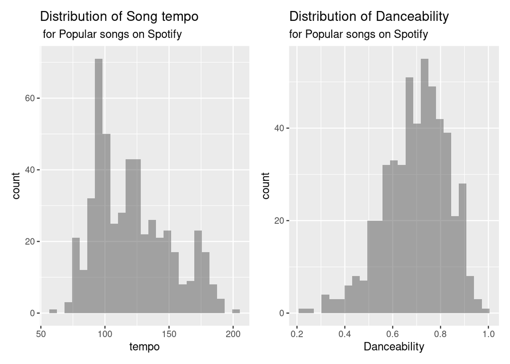

```r
p1 <- gf_histogram(~tempo, data = spotify) |>
  gf_labs(title = "Distribution of Song tempo",
       subtitle = " for Popular songs on Spotify",
       x = "tempo")

p2 <- gf_histogram(~danceability, data = spotify) |>
  gf_labs(title = "Distribution of Danceability",
       subtitle = "for Popular songs on Spotify",
       x = "Danceability")

p1 + p2 # The patchwork package will arrange your plots for you
```

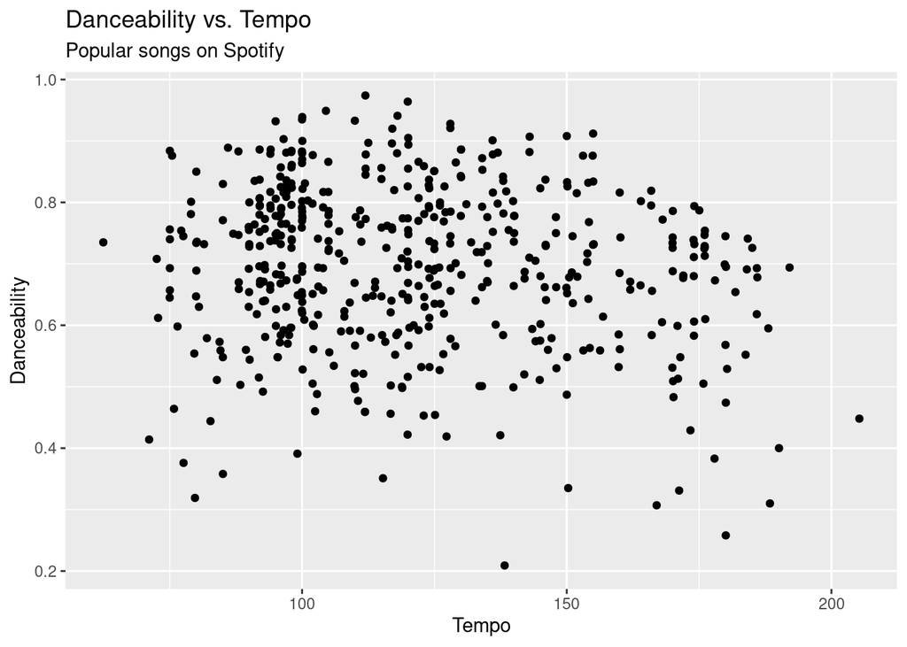

```r
gf_point(danceability ~ tempo, data = spotify) |>
  gf_labs(title = "Danceability vs. Tempo",
       subtitle = "Popular songs on Spotify",
       x = "Tempo",
       y = "Danceability")
```

## Exercise 1

Fit a model using your assigned explanatory variable to predict a songs `danceability`. Use `tidy` and `kable` to neatly display your model and have your reporter write you model on the white board. Be prepared to verbally interpret the slope.

```r
## add code
lm_value <- lm(danceability~tempo, data = spotify )
lm_value |>
  tidy() |>
  kable(digits = 7)
```

| term | estimate | std.error | statistic | p.value |
| --- | --- | --- | --- | --- |
| (Intercept) | 0.7775000 | 0.0247792 | 31.377108 | 0.0000000 |
| tempo | -0.0006717 | 0.0001988 | -3.379635 | 0.0007819 |

## Exercise 2

Write down the null and alternative hypotheses to test whether your explanatory variable is a useful predictor.

$$H_o : \beta_1 = 0$$

There is no relationship between the tempo and the danceability of the songs in the Spotify dataset.

$$H_o : \beta_1 \neq 0$$

There is a relationship between tempo and danceability.

## Exercise 3

Identify the standard error of $\hat{\beta}_1$ and your T-statistic from the output above. Interpret your test statistic. Do you think this provides evidence that your explanatory variable is a useful predictor of `danceability`?

standard error = 0.0001988

```r
t = -0.0006717/0.0001988
t
```

```
[1] -3.378773
```

## Exercise 4

Identify and interpret the p-value in the output from Exercise 1. On the white board, draw a sketch of your p-value.

0.0007819

[output not shown]

## Exercise 5

Based on your p-value, how strong is the evidence that your assigned explanatory variable is a useful predictor of `danceability`?

very stong because it is very close to 0 which basically means it is highly against the null hypothesis.

## Exercise 6

Write a conclusion for your test in the context of the problem.

for the context of this problem, we say there is a a strong evidence for tempo and danceability having a relationship

## Exercise 7

Use `tidy` to compute a (95 - your group number)% confidence interval for your slope.

[output not shown]

```r
tidy(lm_value, conf.int = TRUE, conf.level = 0.91)  |>
  kable(digits = 7)
```

| term | estimate | std.error | statistic | p.value | conf.low | conf.high |
| --- | --- | --- | --- | --- | --- | --- |
| (Intercept) | 0.7775000 | 0.0247792 | 31.377108 | 0.0000000 | 0.7354088 | 0.8195911 |
| tempo | -0.0006717 | 0.0001988 | -3.379635 | 0.0007819 | -0.0010094 | -0.0003341 |

## Exercise 8

On the white board, draw a picture representing the critical value for you confidence interval.

## Exercise 9

Interpret your confidence interval in the context of the problem.

## Exercise 10

Predict the average danceability for a song with:

- an energy score of 0.859
- a loudness score of -5.03
- a valence of 0.52
- a tempo of 125

Report and interpret a 90% confidence interval for the average danceability. Have your reporter write you interval and estimate on the board.

```r
new_songs <- tibble(tempo = 125)
predict(lm_value, newdata = new_songs, interval = "confidence",
        level = 0.90) |>
  kable()
```

| fit | lwr | upr |
| --- | --- | --- |
| 0.6935329 | 0.6839418 | 0.703124 |

## Exercise 11

Report and interpret a 90% confidence interval for a single song with:

- an energy score of 0.859
- a loudness score of -5.03
- a valence of 0.52
- a tempo of 125

```r
new_songs <- tibble(tempo = 125)

predict(lm_value, newdata = new_songs, interval = "prediction",
        level = 0.90) |>
  kable()
```

| fit | lwr | upr |
| --- | --- | --- |
| 0.6935329 | 0.4789351 | 0.9081307 |

## Exercise 12

Would you expect you interval to get wider or narrower if you were making a prediction for all songs with the above characteristics?

i expect our interval to get narrower if we make a prediction for all the songs in our model fit.

**Important**

To submit the AE:

- Render the document to produce the HTML file with all of your work from today’s class.
- Upload your QMD and HTML files to the Canvas assignment.